# Lecture 3：代替性と価格内生性

nested logitとBerry反転｜計量経済学II

Kei Ikegami

## 今日の流れ（90分）

[output not shown]

## Quiz（前回の復習・10分）

- Quiz 3 に解答し、**教員が配布するURLからMicrosoft Formsで提出する**（**5分**、メモ・ノート参照可）
- 学籍番号・氏名を記入する（公開講座の受講者は学籍番号欄に「公開講座」）
- 提出した回答は、成績評価のクイズとして採点する
- 回答を提出したあと、解説（**5分**）

# 導入：logitの光と影

## 前回とのつながり

- 前回：RUM + Gumbel → **logit公式**。最尤法で推定し、弾力性からプライシングまで一気通貫
- logitは驚くほど扱いやすい。ただしその扱いやすさは**強い仮定の代償**
- 今日はその代償を2つ、正面から直視する
  1. **IIA**：代替パターンが「シェア比」だけで機械的に決まる
  2. **価格内生性**：価格は見えない需要ショックと相関している

今日のゴール：nested logitで代替性を柔軟にし、Berry反転 + 操作変数法で価格内生性に対処できるようになること。

## 今日押さえたいこと

1. logitの**IIA**という制約を、シミュレーションと弾力性行列で体感する
2. **nested logit**：財をネストにまとめ、ネスティング・パラメータで「似た財ほど強く競合する」を表現する
3. **Berry (1994) の反転**：市場シェアの対数比を取ると、離散選択がOLSの回帰式に化ける
4. 価格が需要ショックと**正に**相関する典型例で、内生性が価格反応の**過小評価**を生むメカニズムを理解する（負の相関なら向きは逆）
5. コストシフターを操作変数にした**2SLS**で真値を回収できることを確認する

# IIAを直視する

## 古典：赤バス・青バス問題

通勤手段が「車」と「青バス」の2つ。シェアは50%ずつ。

ここに「**赤バス**」（青バスと座席の色以外まったく同じ）が参入したら？

- 直感：赤バスは青バスの完全な代替物 → 車50%・青25%・赤25%
- logitの答え：**車も33%に低下**。青バスと同じだけ車からも客を奪う

## 現代版：缶コーヒー棚ふたたび

3つの財（+ outside option）を考える。

- **財1**：コンビニPBの缶コーヒーA
- **財2**：ほぼ同じ処方・同価格帯のPB缶コーヒーB（財1とほぼ区別がつかない）
- **財3**：方向性の違う高級スペシャルティコーヒー（価格は2倍以上）

問い：**財3が値上げされたら、流出した客はどこへ向かうか？**

そして——財1と財2が「似ている」ことは、この計算に影響するのか？

## 3財logit市場を作る

パラメータ設定：品質は財1・2が同じ、財3は高品質・高価格。

| 財 | シェア |
| --- | --- |
| 財1（PB-A） | 0.2111 |
| 財2（PB-B） | 0.2111 |
| 財3（高級） | 0.0039 |
| outside | 0.5739 |

- 財1と財2は品質・価格が同じなので、シェアも一致
- 財3は高価格が効いてシェア1%未満

## 財3（高級）を10%値上げする

| 財 | 値上げ前 | 値上げ後 | 変化 |
| --- | --- | --- | --- |
| 財1（PB-A） | 0.21112 | 0.21157 | 0.00045 |
| 財2（PB-B） | 0.21112 | 0.21157 | 0.00045 |
| 財3（高級） | 0.00387 | 0.00174 | -0.00213 |

- 財1の需要獲得と財2の需要獲得の比：**1**
- 財1と財2のbaselineシェア比：**1**

→ 流出した需要は**残りの財のシェア比に応じて**機械的に配分される

## 図で見る：財3値上げのシェア変化

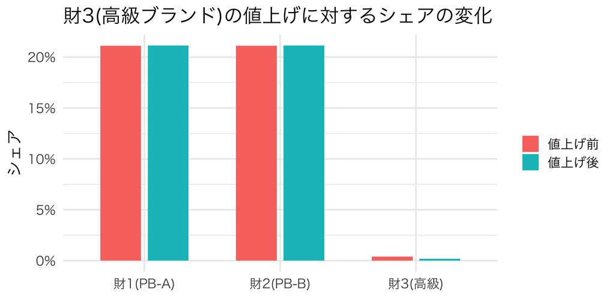

図 1

財1・財2は同じだけ需要を獲得する。「似ている度合い」はどこにも効かない。

## 交差弾力性の式をもう一度

前回の閉形式を思い出す（$k$ が値上げしたときの財 $j$ の反応）：

$$\eta_{jk} = \alpha p_k s_k \quad (j \neq k)$$

- 右辺にあるのは、**値上げした財 $k$ の価格とシェアだけ**
- 反応する側の財 $j$ の情報（品質・財 $k$ との類似度）が**一切入っていない**
- だから、誰が反応しても答えは同じになる

## 弾力性行列で確認する

|  | 財1 | 財2 | 財3 |
| --- | --- | --- | --- |
| 財1 | -2.3666 | 0.6334 | 0.0309 |
| 財2 | 0.6334 | -2.3666 | 0.0309 |
| 財3 | 0.6334 | 0.6334 | -7.9691 |

- 3列目（財3の値上げ）を縦に見る：財1の反応と財2の反応が**完全に同じ**
- どの列でも、非対角成分は列内で同じ値になる

## なぜIIAが起きるのか

原因：効用ショック $\varepsilon_{ijt}$ が財を超えて **iid**（独立同一分布）だという仮定。

- 財1と財2が「似ている」＝ 財1を好む消費者は財2も好みやすい
- つまり本来は $\varepsilon_{i1t}$ と $\varepsilon_{i2t}$ が**正に相関**しているはず
- logitはこの相関を**許さない** → 帰結が IIA

「BMWが値上げしたら、シェア比に応じて軽トラの需要も増える」——これがlogitの機械的な帰結。現実の乗り換え先は同じ高級車セグメントに偏るはずである。

# nested logit

## アイデア：財をグループにまとめる

- 財をあらかじめいくつかの**ネスト（グループ）**に分ける
- **同じネスト**に属する財同士：効用ショックが**相関する**
- **異なるネスト**の財同士：相関しない

→ 「似た財ほど強く競合する」という直感を、構造としてモデルに与える

## ネスト構造の例：缶コーヒー市場

[figure not shown]

図 2

まったり系（A・B）内の代替は強く、ネストをまたぐ代替は相対的に弱い。

## 選択確率の2段階分解

財 $j$ がネスト $g$ に属するとき、選択確率は次のように分解できる：

$$s_{jt} = \bar{s}_{j|g,t} \times s_{gt}$$

- $\bar{s}_{j|g,t}$：ネスト $g$ を選んだ条件のもとでの財 $j$ の確率（**within-nest share**）
- $s_{gt}$：ネスト $g$ 自体が選ばれる確率（between-nest share）

「まずどの系統か、次にその中のどれか」という読み方ができる。

## 式の中身：inclusive value

ネスト $g$ の「まとめた魅力度」（inclusive value）を定義する：

$$I_{gt} = \sum_{k \in g} \exp\left( \delta_{kt} / (1-\rho) \right)$$

within-nest share と between-nest share は

$$\bar{s}_{j|g,t} = \frac{\exp\left( \delta_{jt} / (1-\rho) \right)}{I_{gt}}$$

$$s_{gt} = \frac{I_{gt}^{1-\rho}}{1 + \sum_{g'} I_{g't}^{1-\rho}}$$

## ネスティング・パラメータの意味

核となるパラメータは $\rho \in [0,1)$。$\lambda=1-\rho$ をdissimilarity parameterと呼ぶ：

- $0<\lambda\leq1$（$0\leq\rho<1$）が通常のランダム効用モデルと整合的な範囲
- $\rho$ が大きい → 同じネスト内のショックの相関が強い
- 標準的な正規化では相関は $1-\lambda^2=1-(1-\rho)^2$。**$\rho$自体は相関ではない**
- $\rho=0$ → **plain logitに一致**、$\rho\to1$ → ネスト内代替が極端に強い

nested logitはplain logitを特殊ケース（$\rho = 0$）として含む**一般化**。追加パラメータはたった1つ。

## Rで実装：nested logitのシェア関数

```r
nested_logit_shares <- function(delta, nests, rho) {
  lambda <- 1 - rho
  J <- length(delta)
  IV <- numeric(length(nests))            # 各ネストのinclusive value
  for (g in seq_along(nests)) {
    IV[g] <- sum(exp(delta[nests[[g]]] / lambda))
  }
  denom <- 1 + sum(IV^lambda)
  s_g <- (IV^lambda) / denom              # between-nest share
  s <- numeric(J)
  for (g in seq_along(nests)) {
    for (j in nests[[g]]) {
      s[j] <- exp(delta[j] / lambda) / IV[g] * s_g[g]
    }
  }
  list(s = s, s0 = 1 / denom, s_g = s_g)
}
```

数式の分解（within × between）をそのままコードにしただけ。

## 検算：ネスティング・パラメータを0に近づけると

4財市場（まったり系 = 財1・2、すっきり系 = 財3・4）で確認する。

| 財 | nested logit（ロー = 0付近） | plain logit |
| --- | --- | --- |
| 財1 | 0.19097 | 0.19097 |
| 財2 | 0.12801 | 0.12801 |
| 財3 | 0.12801 | 0.12801 |
| 財4 | 0.12801 | 0.12801 |
| outside | 0.42501 | 0.42501 |

一致した。nested logitはplain logitを内側に含んでいる。

## 実験：財3（すっきり系）を20%値上げ

設定：4財市場、ネスティング・パラメータ $\rho=0.5$。

- まったり系ネスト：財1・財2
- すっきり系ネスト：財3・**財4**（財3の「似た者同士」）
- 財3を20%値上げしたとき、**plain logitとnested logitで流出先はどう違うか**

予想：nested logitでは、財3から流出した客は**同じネストの財4**に集中するはず。

## 結果：代替がネスト内に集中する

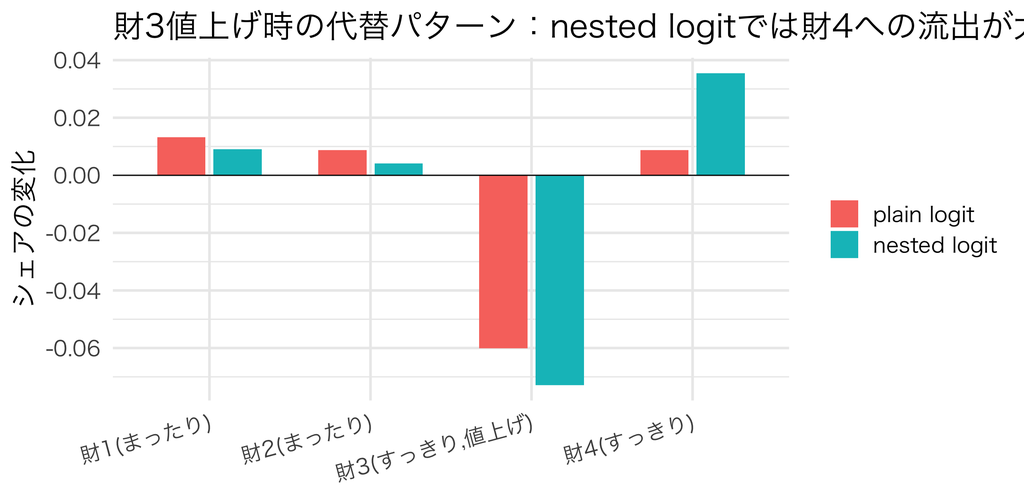

図 3

- plain logit：財1・2・4にほぼ均等（シェア比）に配分
- nested logit：**同じネストの財4への流出がはっきり大きい**

## 弾力性でも確認する

財3の値上げに対する各財の弾力性（数値微分で計算）：

| 財 | plain logit | nested logit |
| --- | --- | --- |
| 財1（まったり） | 0.448 | 0.379 |
| 財2（まったり） | 0.448 | 0.379 |
| 財3（自己弾力性） | -3.052 | -4.871 |
| 財4（すっきり） | 0.448 | 2.129 |

- plain logit：財1・2・4の交差弾力性が**すべて同じ値**（IIA）
- nested logit：**同じネストの財4だけ**が大きく反応する

## ここが核心：たった1つの追加パラメータ

- IIAの原因は「効用ショックが財を超えてiid」という仮定
- nested logitはネスト内の依存をパラメータ1つで許し、「似た財ほど強く競合する」を表現する
- $\rho$は相関そのものではないが相関を単調に動かし、$\rho=0$でplain logitに戻る
- ネスト構造は分析者が事前に決める必要がある——この限界は次回のrandom coefficient logitで解消する

# Berry (1994) の反転

## 現実のデータ：個票はないことが多い

- ここまでは「誰が何を選んだか」という**個票データ**を前提にしてきた
- 実務のPOSデータ・スキャナーデータは多くの場合、**市場ごと・製品ごとのシェアと価格**の集計値だけ
- 製品別購入者数と市場規模が分かれば、集計カウントの多項尤度は組める
- シェアしかなく市場規模・標本抽出過程が不明なら、カウント尤度の情報量は定まらない

尤度を直接最大化せず、市場シェアを反転して需要を推定できないか？ → **できる**（Berry 1994）

## シェアの比を取ると分母が消える

市場 $t$ のlogitシェアとoutsideシェア：

$$s_{jt} = \frac{\exp(\delta_{jt})}{1 + \sum_{k=1}^{J} \exp(\delta_{kt})}$$

$$s_{0t} = \frac{1}{1 + \sum_{k=1}^{J} \exp(\delta_{kt})}$$

2つの比を取ると、面倒な分母がきれいに消える：

$$\frac{s_{jt}}{s_{0t}} = \exp(\delta_{jt})$$

## Berry反転：回帰式が出てくる

両辺の対数を取る：

$$\ln s_{jt} - \ln s_{0t} = \delta_{jt} = x_{jt}'\beta - \alpha p_{jt} + \xi_{jt}$$

- 左辺：観測されたシェアから**直接計算できる**
- 右辺：属性と価格の**線形回帰式**そのもの

「個々の消費者の離散選択」という複雑な問題が、「シェアの対数比を被説明変数とする回帰」という計量Iでおなじみの問題に化ける。個票がなくても需要が推定できる。

## nested logit版のBerry反転

nested logitでも同様に反転できる（within-nest shareを使って比を取る）：

$$\ln s_{jt} - \ln s_{0t} = x_{jt}'\beta - \alpha p_{jt} + \rho \ln \bar{s}_{j|g,t} + \xi_{jt}$$

- plain logitの式に **within-nest shareの対数**が1項加わっただけ
- ネスティング・パラメータが0ならplain logitの式に一致

右辺の within-nest share は「シェアから作った変数」なので、価格と同じく**内生変数**。同じネストの財の需要ショックに依存して決まるため、OLSではネスティング・パラメータの推定も歪む。

# 価格内生性の正体

## 見えない需要ショックの中身

$\xi_{jt}$（観測されない需要ショック）の具体例：

- 未観測の品質：パッケージデザイン、口コミでの評判
- 広告・販促の強さ（データセットに含まれていない場合）
- 店頭の棚位置・陳列面積

分析者には見えない。しかし——**企業には見えている**。

## 企業はシェアの裏側を知って値付けする

- $\xi_{jt}$ が高い（人気がある・話題になっている）商品ほど、企業は「多少値上げしても売れる」と判断し、**強気の価格**をつける

観測属性$x$を取り除いた価格残差を$\tilde p_{jt}$と書けば、典型的には

$$\operatorname{Cov}(\tilde p_{jt}, \xi_{jt}) > 0$$

- Berry反転の回帰式では $\xi_{jt}$ が誤差項の位置にいる
- → 説明変数（価格）と誤差項が相関する：**計量Iで学んだ内生性そのもの**

## バイアスの方向：価格反応の過小評価

価格の係数は $-\alpha$（$\alpha > 0$）。$x$を条件づけた価格残差と$\xi$の共分散が正なら：

$$\operatorname{plim}\hat b_p=-\alpha+
\frac{\operatorname{Cov}(\tilde p,\xi)}{\operatorname{Var}(\tilde p)}$$

- OLSの価格係数は真の $-\alpha$ より**0に近く**推定される
- つまり $\alpha$ を**過小評価** → 需要が実際より**非弾力的**に見える

「値上げしてもあまり客が離れないようです。強気の値上げを提案しましょう」——過小評価された弾力性に基づくこの提案は、想定以上の客離れを招く。値付けにも合併審査にも直結する実害。

# シミュレーション：OLSのバイアスと2SLS

## DGPの設計：100市場×4財

市場 $t = 1, \ldots, 100$、財 $j = 1, \ldots, 4$ のplain logit市場。真値は価格係数 2.0、属性係数 1.5。

- $x_{jt}$：観測される商品属性
- $w_{jt}$：**コストシフター**（限界費用を動かす。需要ショックとは無相関に生成）
- $\xi_{jt}$：観測されない需要ショック
- 限界費用：コストシフターで決まる
- 価格 = 限界費用 + マークアップ、**マークアップは需要ショックに反応**

## 価格をつくる：マークアップが需要ショックに反応

```r
kappa <- 1.1   # 内生性の強さ（markupがxiにどれだけ反応するか）

mc_mkt     <- 1.0 + 0.8 * w_mkt +
              matrix(rnorm(T_mkt * J_mkt, sd = 0.3), nrow = T_mkt, ncol = J_mkt)
markup_mkt <- pmax(1.0 + kappa * xi_mkt, 0.05)
price_mkt  <- mc_mkt + markup_mkt

cat("corr(price, xi):", round(cor(as.vector(price_mkt), as.vector(xi_mkt)), 3), "\n")
```

```
corr(price, xi): 0.585
```

想定通り、価格と需要ショックの間に正の相関が生まれている。

## 生成されたデータ：価格とシェアの散布図

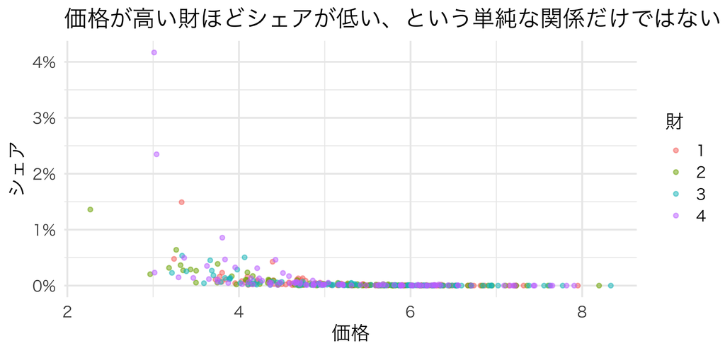

図 4

需要ショックの効果が混ざっているため、散布図から弾力性は読み取れない。

## OLSでBerry反転を推定する

```r
ols_fit <- feols(y_berry ~ price + x, data = market_df, vcov = "hetero")
alpha_ols <- -coef(ols_fit)["price"]

cat("alpha_true =", alpha_true, "\n")
```

```
alpha_true = 2
```

```r
cat("alpha_hat(OLS) =", round(alpha_ols, 3), "\n")
```

```
alpha_hat(OLS) = 1.664
```

- 真値 2.0 に対して、OLSの推定値は**はっきり小さい**
- 理屈通り、価格反応を過小評価している

## 2SLS：コストシフターを操作変数に

コストシフター $w_{jt}$ は価格を動かすが、$\xi_{jt}$ には影響しない（DGPでそう設計した）。

```r
iv_fit <- feols(y_berry ~ x | price ~ w, data = market_df, vcov = "hetero")
alpha_iv <- -get_coef_for(iv_fit, "price")

cat("alpha_hat(OLS)  =", round(alpha_ols, 3), "\n")
```

```
alpha_hat(OLS)  = 1.664
```

```r
cat("alpha_hat(2SLS) =", round(alpha_iv, 3), "\n")
```

```
alpha_hat(2SLS) = 1.976
```

- `fixest` のIV構文：被説明変数 ~ 外生変数 | 内生変数 ~ 操作変数
- 2SLSの推定値は真値 2.0 のすぐ近くまで戻ってくる

## 真値回収の確認

| 推定方法 | 価格係数の推定値 |
| --- | --- |
| 真値 | 2.000 |
| OLS | 1.664 |
| 2SLS | 1.976 |

DGPを自分で書いたからこそ、「OLSは真値を外し、2SLSは回収する」という比較ができる。**真値回収の確認**は今回も推定の正しさを支える柱。

## excluded-IV partial F：弱操作変数の診断

含まれる外生変数 $x$ を条件づけても、除外IV $w$ が価格を説明するか確認する。回帰全体のFではなく、$w$の**partial F**を見る。

```
[1] 710.9917
```

- 今回のpartial Fは十分大きく、極端に弱い関連性の兆候はない
- 「F>10」は古典的な大まかな経験則。異分散・複数内生変数ではKPやSW conditional F、弱IV頑健推論も使う

## 弾力性への波及：自己価格弾力性の比較

価格係数の推定値が変われば、すべての弾力性計算が変わる（市場平均で評価）：

| 財 | 真値ベース | OLSベース | 2SLSベース |
| --- | --- | --- | --- |
| 財1 | -10.609 | -8.825 | -10.484 |
| 財2 | -10.578 | -8.800 | -10.453 |
| 財3 | -10.782 | -8.969 | -10.655 |
| 財4 | -10.544 | -8.771 | -10.419 |

OLSベースの自己弾力性は絶対値が一様に小さい ＝ 需要が非弾力的に**見えてしまう**。

## ここが核心

- 価格は未観測の需要ショックと正に相関する（企業がショックを知って値付けするため）
- この正の相関を無視したOLSは価格反応を**過小評価**し、需要を実際より非弾力的に見せる（相関が負ならバイアスの向きも逆）
- コストシフターを操作変数にした2SLSで真値を回収できる（first-stage Fで関連性を診断）
- 誤った弾力性行列は、値付けでも合併審査でも意思決定を大きく誤らせる

# IVの品揃え

## その1：コストシフター

原材料費、賃金、為替レート、税制変更など、**限界費用を動かす変数**。

- 識別の仮定：価格には（費用を通じて）効くが、需要ショックとは無相関
- さきほどのシミュレーションで使ったのがこれ

危ない場面：原材料費の高騰が品質改善（オーガニック素材への切り替え等）を伴うと、需要ショックも同時に動き、除外制約が壊れる。

## その2：Hausman型IV（他市場の同一製品の価格）

同じ製品が複数の地域市場で売られているとき、**他市場での同一製品の価格**をIVに使う（Hausman 1996）。

- 識別の仮定：全国共通のコスト構造は市場を横断して価格に反映される一方、需要ショックは市場ごとに独立

Bresnahanらの批判：全国的な広告キャンペーンやトレンドのように**需要ショックが全国で同時に動く**場合、他市場の価格と自市場のショックが相関し、除外制約が崩れる。

## その3：BLP型IV（自社他製品・競合製品の属性）

自財の外生属性に加え、**同じ企業の他製品属性の和**と**他企業の製品属性の和**を別々に作る（Berry, Levinsohn and Pakes 1995）。

- 直感：自社ラインナップと競合の位置がマークアップを変え、自財価格を動かす
- 識別の仮定：観測属性を条件づけると、他製品属性は自財の未観測需要ショックと無相関
- 発展形として、競合属性との「距離」を使う differentiation IV（Gandhi and Houde 2019）がある

# まとめ

## 今日のまとめ

- logitのIIA：代替が「シェア比」だけで決まり、財の類似性を反映できない（原因はiidのショック）
- nested logit：ネスティング・パラメータ1つで「似た財ほど強く競合する」を表現。$\rho$は相関そのものではなく、0でplain logitに一致
- Berry反転：$\ln s_{jt} - \ln s_{0t} = \delta_{jt}$ により、市場シェアデータの回帰で需要を推定できる
- 価格と需要ショックの条件付き共分散が正 → OLSは価格反応を過小評価（負ならバイアスの向きも逆）
- コストシフター・Hausman型・BLP型のIVによる2SLSで対処。ただし除外制約は無料ではない

## 宿題

- Rシミュ3の `kappa`（内生性の強さ）を0から3まで動かし、OLSと2SLSの価格係数推定値がどう動くか折れ線グラフを描く。`kappa = 0` でOLSと2SLSがほぼ一致することも確認する
- 生成AIに「nested logitのwithin-nest shareが内生変数になるのはなぜか」と質問し、返ってきた説明が今日の内容と整合的か検討する
- **coding課題は `assignment3.qmd`**：市場レベルデータのDGP→Berry反転→OLS vs 2SLSを自分の手で実装

## 次回予告：ネストを決めずに柔軟な代替性を

- nested logitの限界：ネスト構造を**分析者が事前に決める**必要がある
- 次回は **random coefficient logit（BLPモデル）**：消費者ごとに価格感応度・好みが異なる構造を入れ、ネストなしで柔軟な代替パターンをデータから推定する
- その先にあるのは**合併分析**：合併後にどれだけ値上げが起きるかの予測

**Reading**：上武ほか『実証ビジネス・エコノミクス』、Berry, Levinsohn and Pakes (1995)